# BR PS 8

AP

10/20/2021

## Exercise 8.1

The three common tasks in posterior analysis are posterior estimation, posterior hypothesis testing, and posterior prediction.

## Exercise 8.2

### Part A

A drawback to reporting only the central tendency is that it makes posteriors with very different levels of confidence/certainty seem like they’re the same; including a measure of spread lets us see how precise our posterior is.

### Part B

There’s a 95% chance that lambda is somewhere between 1 and 3.4.

## Exercise 8.3

### Part A

Yes!
$$H_{0}: P(license) \le 0.4$$
$$H_{a}: P(license) \gt 0.4$$

### Part B

No!

### Part C

Yes!
$$H_{0}: P(support) \le 0.6$$

$$H_{a}: P(support) \gt 0.6$$

### Part D

Yes!

$$H_{0}: \lambda = 3$$

$$H_{a}: \lambda \ne 3$$

## Exercise 8.4

### Part A

Posterior odds are our updated understanding of a parameter; basically, how much more (or less) likely that parameter is to be against the null vs. with the null, based on our updated posterior model.

### Part B

Prior odds are the initial understanding of a parameter; the same as the above, but based on the prior model.

### Part C

The Bayes Factor essentially tells us how much more confident we are in our posterior vs. our prior. You might want to calculate it to see how convincing your findings are.

## Exercise 8.5

### Part A

Posterior predictive models incorporate uncertainty about both sampling variability (the actual value of the sample statistic in whatever sample we happen to get, which could be anywhere around the actual parameter) and posterior variability (the fact that our most likely estimate for the parameter isn’t the only possible value of the parameter).

### Part B

You’ve done a few polls in a county for your candidate, and you want to predict how many voters in that county will vote for them in the election to see if it’s enough to flip the state in your favor.

### Part C

Both! Posterior predictive model is…
$$f(y'|y) = \int f(y'|\pi)f(\pi|y)d\pi$$
…where y is the data and $\pi$ is the parameter.

## Exercise 8.6

### Part A

```r
qbeta(c(.025,.975), 4, 5)
```

```
## [1] 0.1570128 0.7551368
```

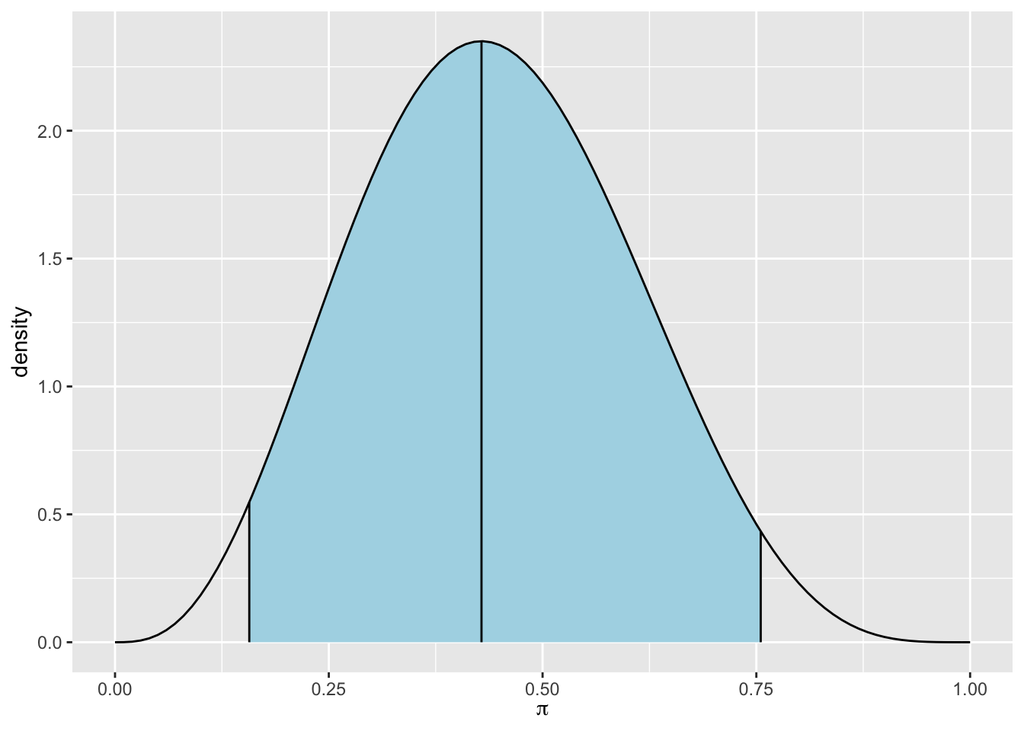

```r
plot_beta_ci(4,5,ci_level=.95)
```

95% CI: (0.157, 0.755)

### Part B

```r
qbeta(c(.2,.8), 4, 5)
```

```
## [1] 0.3032258 0.5836554
```

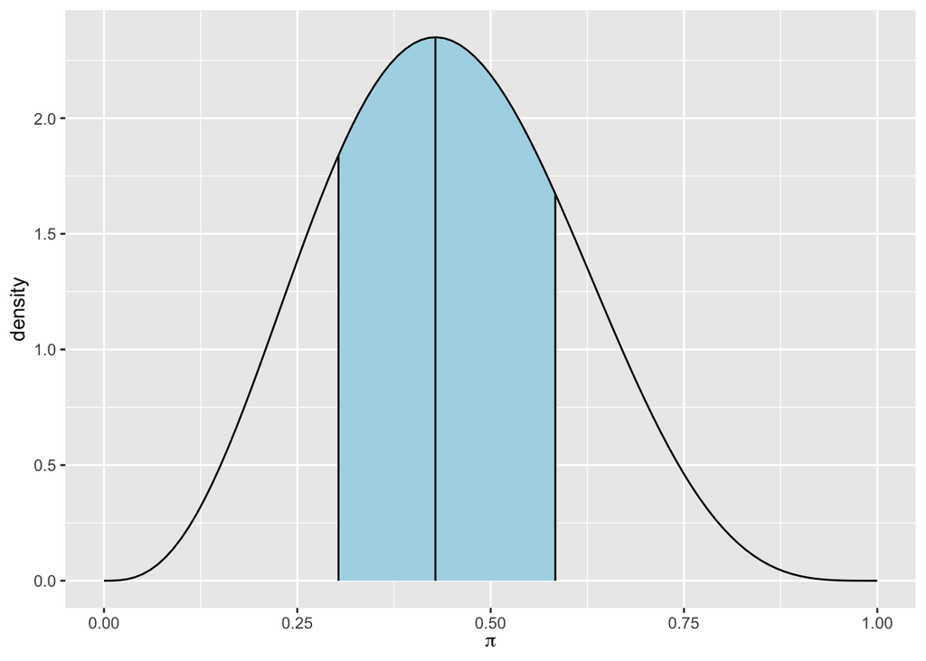

```r
plot_beta_ci(4,5,ci_level=.6)
```

60% CI: (.303, .584)

### Part C

```r
qgamma(c(.025,.975), 1, 8)
```

```
## [1] 0.003164726 0.461109932
```

95% CI: (0.003, 0.461)

## Exercise 8.7

### Part A

```r
qgamma(c(.005, .995), 1, 5)
```

```
## [1] 0.001002508 1.059663473
```

99% CI: (.001, 1.06)

### Part B

```r
qnorm(c(.025, .975), mean=10, sd=2)
```

```
## [1]  6.080072 13.919928
```

95% CI: (6.08, 13.92)

### Part C

```r
qnorm(c(.1, .9), mean=-3, sd=1)
```

```
## [1] -4.281552 -1.718448
```

80% CI: (-4.28, -1.72)

## Exercise 8.8

### Part A

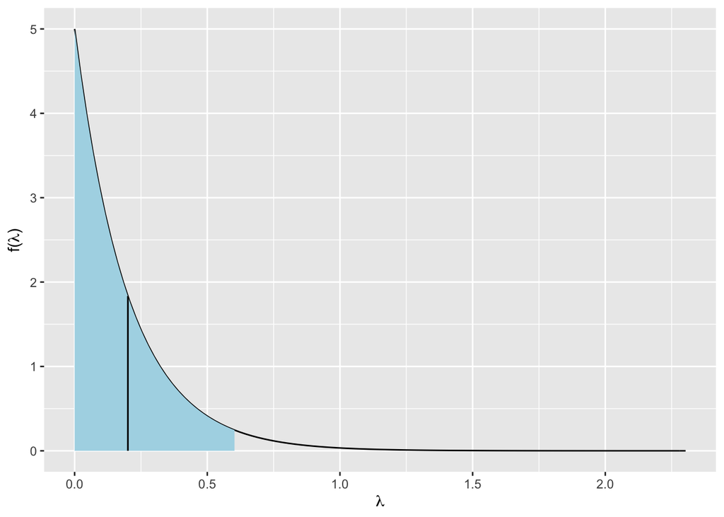

```r
set.seed(18)
dist88 <- rgamma(100000, shape=1, rate=5)
hdi1 <- as.vector(hdi(dist88, .width=.95))

plot_gamma(1,5) +
  stat_function(fun = dgamma,
                  args = list(1, 5),
                  xlim = hdi1,
                  geom = "area",
                  fill = "lightblue") +
  geom_segment(aes(x=mean(dist88), xend=mean(dist88), y=0,
                   yend=dgamma(mean(dist88), 1, 5)))
```

### Part B

```r
ci1 <- qgamma(c(.025, .975), 1, 5)
summarize_gamma(1,5)
```

```
##   mean mode  var  sd
## 1  0.2    0 0.04 0.2
```

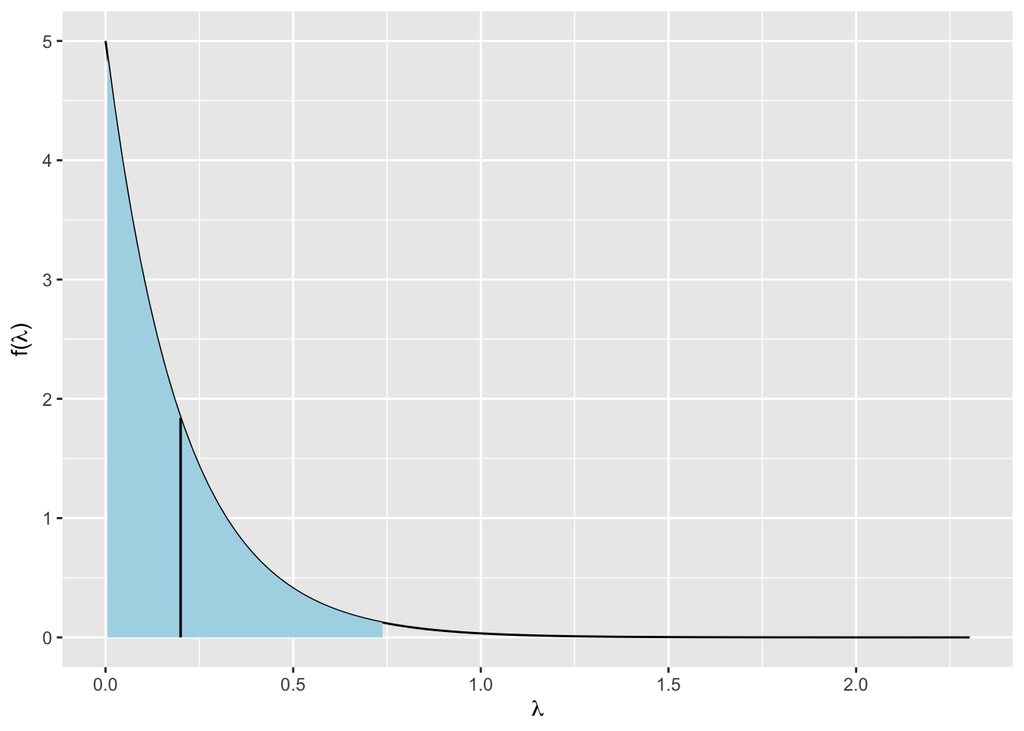

```r
mean <- .2
plot_gamma(1,5) +
  stat_function(fun = dgamma,
                  args = list(1, 5),
                  xlim = ci1,
                  geom = "area",
                  fill = "lightblue") +
  geom_segment(aes(x=mean, xend=mean, y=0,
                   yend=dgamma(mean, 1, 5)))
```

### Part C

These two intervals are not the same. The one in Part A is shifted slightly to the left; this is because the Gamma(1,5) distribution is highly skewed right. In this case, I think that the HDI is more appropriate, because it captures the mode better than the CI.

### Part D

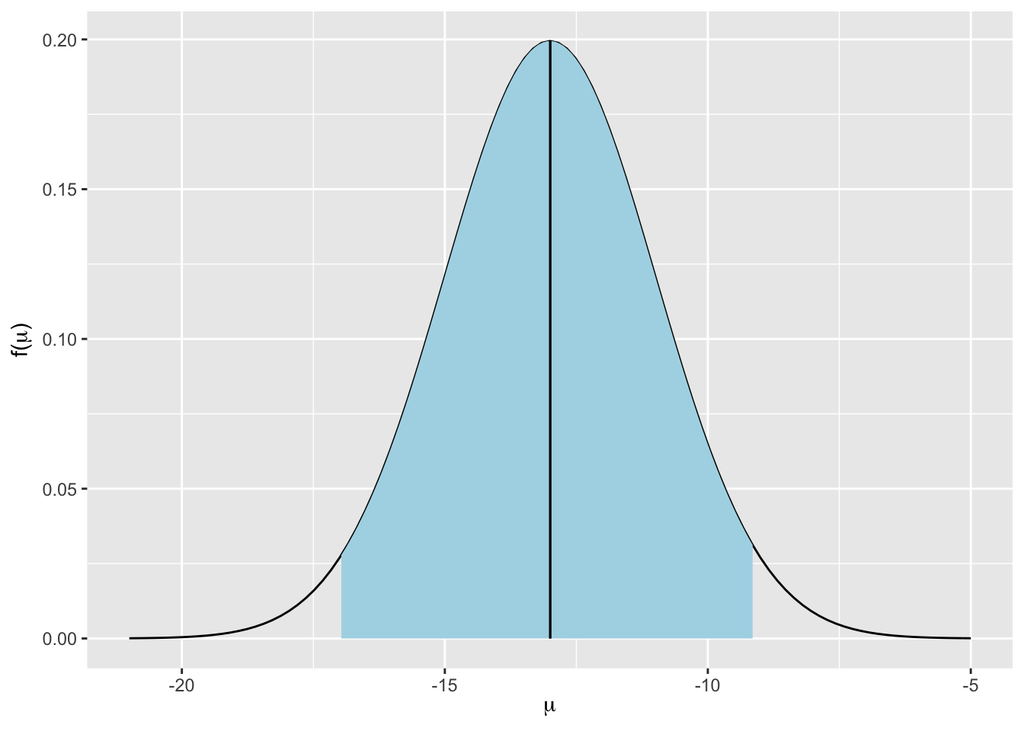

```r
dist88d <- rnorm(100000, mean=-13, sd=2)
hdi2 <- as.vector(hdi(dist88d, .width=.95))

plot_normal(-13,2) +
  stat_function(fun = dnorm,
                  args = list(-13, 2),
                  xlim = hdi2,
                  geom = "area",
                  fill = "lightblue") +
  geom_segment(aes(x=mean(dist88d), xend=mean(dist88d), y=0,
                   yend=dnorm(mean(dist88d), -13, 2)))
```

### Part E

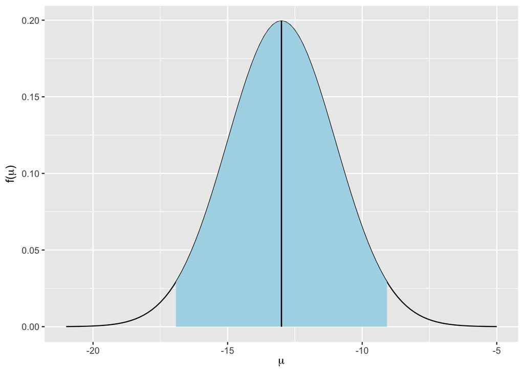

```r
ci2 <- qnorm(c(.025, .975), -13, 2)
plot_normal(-13,2) +
  stat_function(fun = dnorm,
                  args = list(-13, 2),
                  xlim = ci2,
                  geom = "area",
                  fill = "lightblue") +
  geom_segment(aes(x=-13, xend=-13, y=0,
                   yend=dnorm(-13, -13, 2)))
```

### Part F

Because the normal distribution is not skewed, the HDI and the CI are essentially the same.

## Exercise 8.9

### Part A

```r
post_prob89 <- pbeta(.4, 4, 3, lower.tail=FALSE)
post_prob89
```

```
## [1] 0.8208
```

### Part B

```r
post_odds89 <- post_prob89 / (1 - post_prob89)
post_odds89
```

```
## [1] 4.580357
```

It’s about 4.5 times as likely that pi > .4 than that pi ≤ .4 based on the posterior model.

### Part C

```r
prior_prob89 <- pbeta(0.4, 1, .8, lower.tail = FALSE)
prior_odds89 <- prior_prob89 / (1-prior_prob89)
prior_odds89
```

```
## [1] 1.98098
```

It’s about 2 times as likely that pi > .4 than that pi ≤ .4 based on the prior model.

### Part D

```r
bf89 <- post_odds89 / prior_odds89
bf89
```

```
## [1] 2.312168
```

We’re about twice as confident in our answer now as we were before.

### Part E

Through our analysis, we’re pretty sure that pi > .4, because this is the most plausible answer by a factor of 4.5. Our data helped us by doubling our confidence in our final analysis.

## Exercise 8.10

### Part A

```r
post_prob810 <- pnorm(5.2, 5, 3)
post_prob810
```

```
## [1] 0.5265765
```

### Part B

```r
post_odds810 <- post_prob810 / (1 - post_prob810)
post_odds810
```

```
## [1] 1.112274
```

There’s a slightly greater chance that mu < 5.2 than that mu ≥ 5.2.

### Part C

```r
prior_prob810 <- pnorm(5.2, 10, 10)
prior_odds810 <- prior_prob810 / (1 - prior_prob810)
prior_odds810
```

```
## [1] 0.4611631
```

It’s about twice as likely that mu ≥ 5.2 than that mu < 5.2. (or…It’s about half as likely that mu < 5.2 than that mu ≥ 5.2.)

### Part D

```r
bf810 <- post_odds810 / prior_odds810
bf810
```

```
## [1] 2.411888
```

We’re about 2.5 times more confident in our model now than we were before.

### Part E

Even though our data helped us build a model that we’re much more confident in, it’s essentially equally plausible that mu < 5.2 or that mu ≥ 5.2, so we can’t make a definitive statement on our hypotheses.

## Exercises 8.11 - 8.13

## Exercise 8.14

### Part A

Beta-Binomial is the most appropriate for this analysis, because it’s a success/failure event (either they believe or don’t believe in climate change) with a fixed probability of success (the proportion that do not believe in climate change).

### Part D

```r
pulse_of_the_nation |>
  tabyl(climate_change) |>
  adorn_totals("row")
```

```
##                 climate_change    n percent
##                Not Real At All  150   0.150
##      Real and Caused by People  655   0.655
##  Real but not Caused by People  195   0.195
##                          Total 1000   1.000
```

Sample proportion is .15.

### Part E

```r
# Specifying posterior model
summarize_beta_binomial(1, 2, y=150, n=1000)
```

```
##       model alpha beta      mean      mode          var         sd
## 1     prior     1    2 0.3333333 0.0000000 0.0555555556 0.23570226
## 2 posterior   151  852 0.1505484 0.1498501 0.0001273741 0.01128601
```

```r
  # post model: Beta(151,852)
qbeta(c(.025, .975), 151, 852)
```

```
## [1] 0.1291000 0.1733164
```

The 95% CI is (.129, .173), which means that plausible values of the proportion of adults that don’t believe in climate change lie in between 12.9% and 17.3%.

## Exercise 8.15

### Part A

The credible interval from above is (.129, .173) which means that plausible guesses for the proportion of adults that don’t believe in climate change are between 12.9% and 17.3%. This makes me pretty confident that more than 10% of people don’t believe in climate change - although a proportion of at or below .1 is definitely possible, it’s not very likely.

### Part B

```r
pbeta(.1, 151, 852, lower.tail = FALSE)
```

```
## [1] 0.9999997
```

The posterior probability of p > .1 is essentially 1; based on our updated knowledge, it is almost certain that at least 10% of people don’t believe in climate change.

### Part C

```r
post_prob815 <- .9999997
post_odds815 <- post_prob815 / (1 - post_prob815)
prior_prob815 <- pbeta(.1, 1, 2, lower.tail = FALSE)
prior_odds815 <- prior_prob815 / (1 - prior_prob815)
bf815 <- post_odds815 / prior_odds815
bf815
```

```
## [1] 781892.8
```

### Part D

I can confidently say that pi is greater than .1.

## Exercise 8.16

### Part A

```stan
data {int <lower = 0, upper = 1000> Y;}
parameters {real <lower = 0, upper = 1> pi;}
model {Y ~ binomial(1000, pi);
        pi ~ beta(1, 2);}
```

```r
sim816 <- stan(model_code = model816@model_code, data = list(Y = 150),
               chains = 4, iter = 10000*2, seed=18)
```

### Part B

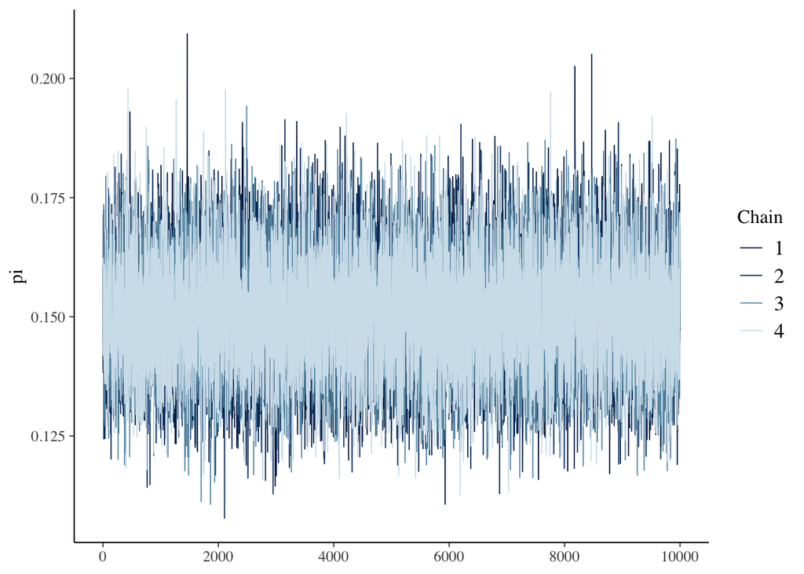

```r
mcmc_trace(sim816, pars="pi")
```

The trace plots look good! There’s no places where it gets “stuck” and no clear trend up or down, which means it’s mixing fast enough.

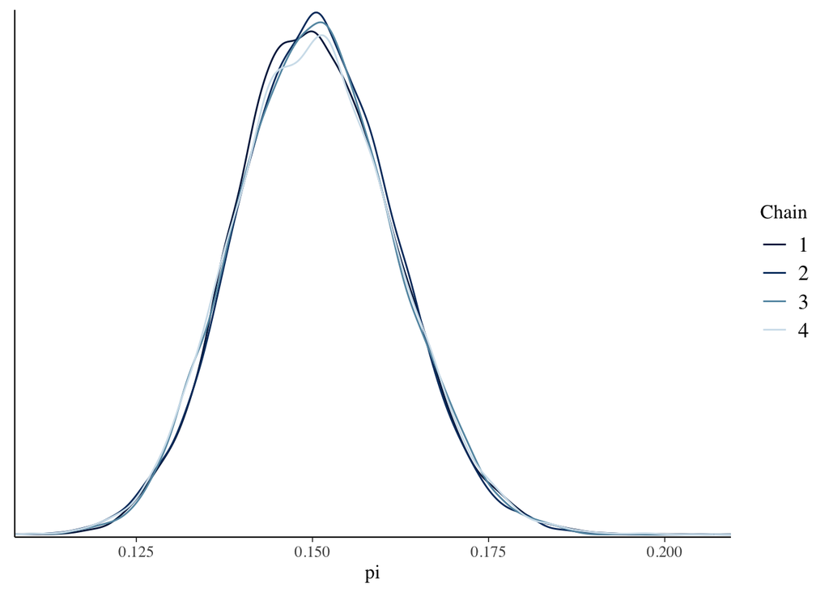

```r
mcmc_dens_overlay(sim816, pars = "pi")
```

The density plots look good - it looks like the most likely value for pi is around .15.

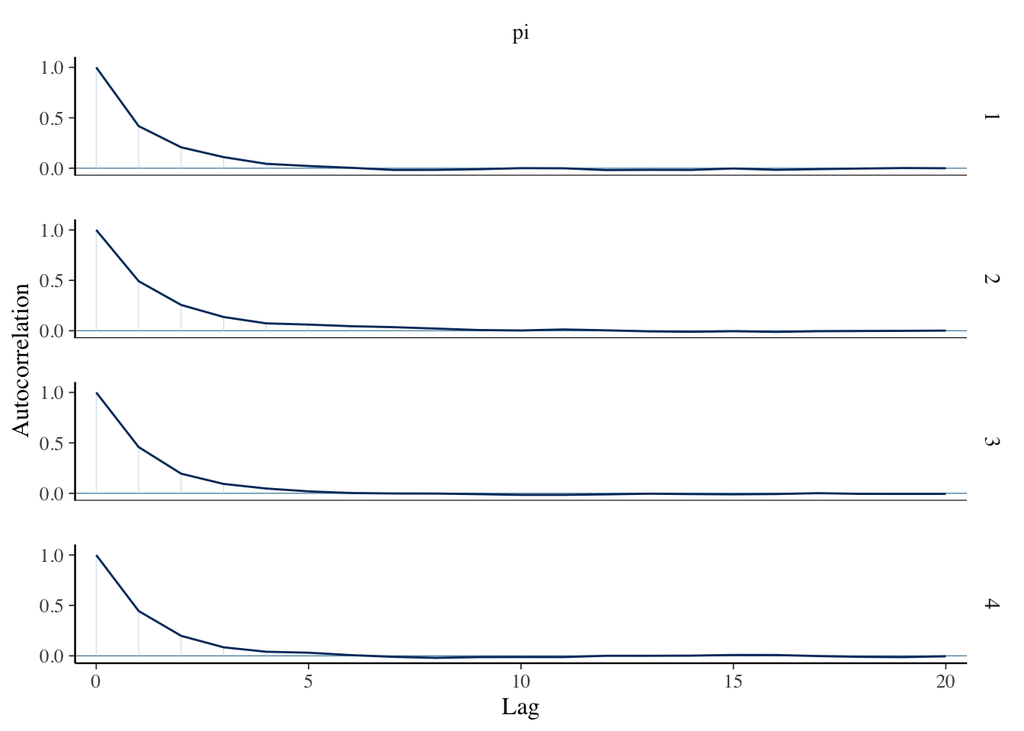

```r
mcmc_acf(sim816, pars = "pi")
```

The autocorrelation for all four chains essentially disappears after a lag of 5, which is good because we can assume that it approximates an independent sample.

### Part C

```r
neff_ratio(sim816, pars = "pi")
```

```
## [1] 0.3645845
```

An effective sample size ration of .36 means that this simulation is as effective as an independent sample of 36% of the size. This is an ok number.

```r
rhat(sim816, pars = "pi")
```

```
## [1] 1.000031
```

The R-hat value is below 1.05, which is good: it means that the variance across all of the chains is equal to the variance inside one chain.

## Exercise 8.17

```r
sim816df <- as.data.frame(sim816, pars = "lp__", include=FALSE)

# direct calculation
sim816df |>
  summarize(
    lower95 = quantile(pi, .025),
    upper95 = quantile(pi, .975)
    )
```

```
##     lower95   upper95
## 1 0.1290964 0.1730766
```

```r
# tidy() shortcut
tidy(sim816, conf.int = TRUE, conf.level = .95)
```

```
## # A tibble: 1 × 5
##   term  estimate std.error conf.low conf.high
##   <chr>    <dbl>     <dbl>    <dbl>     <dbl>
## 1 pi       0.150    0.0112    0.129     0.173
```

95% CI: (.129, .173).

### Part B

```r
sim816df |>
  mutate(htest = pi > .10) |>
  tabyl(htest)
```

```
##  htest     n percent
##   TRUE 40000       1
```

P(pi > .1) = 1

### Part C

To three decimal places, these values are the same as what we got with the previous question. Nice!

## Exercise 8.18

### Part A

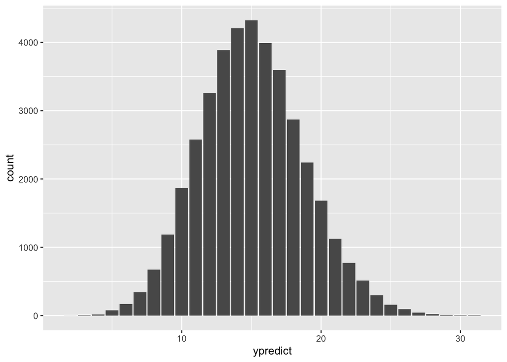

```r
sim816df <- sim816df |>
  mutate(ypredict = rbinom(length(pi), size=100, prob=pi))
ggplot(sim816df, aes(x=ypredict)) +
  stat_count()
```

### Part B Somewhere between 3 and 31 people of the 100 will not believe in climate change; the most likely value is around 15.

### Part C

```r
sim816df |>
  mutate(ytest = ypredict >= 20) |>
  tabyl(ytest)
```

```
##  ytest     n  percent
##  FALSE 35273 0.881825
##   TRUE  4727 0.118175
```

## Exercise 8.19

### Part A

Normal-Normal is the most appropriate; we’re looking for the typical value of a variable.

### Part B

Normal(200, $30^2$)

### Part C

```r
glimpse(penguins_bayes)
```

```
## Rows: 344
## Columns: 9
## $ species              <fct> Adelie, Adelie, Adelie, Adelie, Adelie, Adelie, A…
## $ island               <fct> Torgersen, Torgersen, Torgersen, Torgersen, Torge…
## $ year                 <int> 2007, 2007, 2007, 2007, 2007, 2007, 2007, 2007, 2…
## $ bill_length_mm       <dbl> 39.1, 39.5, 40.3, NA, 36.7, 39.3, 38.9, 39.2, 34.…
## $ bill_depth_mm        <dbl> 18.7, 17.4, 18.0, NA, 19.3, 20.6, 17.8, 19.6, 18.…
## $ flipper_length_mm    <int> 181, 186, 195, NA, 193, 190, 181, 195, 193, 190, …
## $ body_mass_g          <int> 3750, 3800, 3250, NA, 3450, 3650, 3625, 4675, 347…
## $ above_average_weight <fct> 0, 0, 0, NA, 0, 0, 0, 1, 0, 1, 0, 0, 0, 0, 1, 0, …
## $ sex                  <fct> male, female, female, NA, female, male, female, m…
```

```r
penguins_bayes |>
  filter(species == "Adelie") |>
  select(flipper_length_mm) |>
  drop_na() |>
  summarize(meanfl = mean(flipper_length_mm),
            samplen = n(),
            sd = sd(flipper_length_mm))
```

```
## # A tibble: 1 × 3
##   meanfl samplen    sd
##    <dbl>   <int> <dbl>
## 1   190.     151  6.54
```

There are 151 data points, for which the mean flipper length is 189.95mm.

### Part D

```r
summarize_normal_normal(mean = 200, sd = 30, sigma = 6.54, y_bar = 189.954, n = 151)
```

```
##       model     mean     mode         var         sd
## 1     prior 200.0000 200.0000 900.0000000 30.0000000
## 2 posterior 189.9572 189.9572   0.2831665  0.5321339
```

The posterior model is Normal(189.96, $0.53^2$).

```r
qnorm(c(.025, .975), mean = 189.957, sd = 0.532)
```

```
## [1] 188.9143 190.9997
```

A 95% CI would be (188.9, 191.0).

## Exercise 8.20

### Part A

$$H_{0}: \mu \in (200, 220)$$
$$H_{a}: \mu \not\in (200,220)$$

### Part B

Based on the credible interval from the previous exercise, I would say it’s very unlikely that mu is between 200 and 220, since it’s probably lower.

### Part C

```r
pnorm(200, mean = 189.957, sd = 0.532, lower.tail = FALSE) - pnorm(220, mean = 189.957, sd = 0.532, lower.tail = FALSE)
```

```
## [1] 8.680327e-80
```

There is essentially no probability that my hypothesis is true in light of the data.

### Part D

I can confidently say that the average flipper length of Adelie penguins is not between 200 and 220 mm, and in fact lies somewhere below that interval.

## Exercise 8.21

### Part A

Since we’re looking for an expected value of counts, Gamma-Poisson makes the most sense.

### Part B

So, I want s/r to be 2, and for the gamma model to spread to between 0 and 4, so after some trial and error…

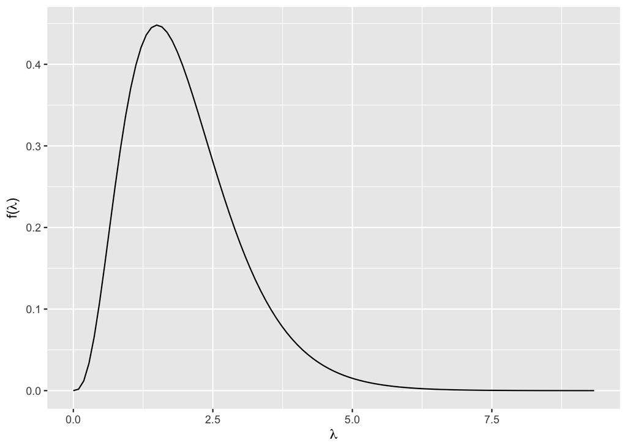

```r
plot_gamma(4,2)
```

…Gamma(4,2) seems to be a reasonable prior.

### Part C

```r
glimpse(loons)
```

```
## Rows: 18
## Columns: 5
## $ year           <dbl> 2000, 2001, 2002, 2003, 2004, 2005, 2006, 2007, 2008, 2…
## $ count          <dbl> 0, 7, 0, 1, 1, 4, 1, 4, 2, 2, 0, 9, 3, 0, 5, 7, 2, 5
## $ hours          <dbl> 143.50, 153.50, 228.30, 248.75, 203.75, 245.75, 223.00,…
## $ count_per_hour <dbl> 0.000000000, 0.045602606, 0.000000000, 0.004020101, 0.0…
## $ count_per_100  <dbl> 0, 5, 0, 0, 0, 2, 0, 2, 1, 1, 0, 4, 2, 0, 3, 3, 1, 3
```

```r
loons |>
  select(count_per_100) |>
  drop_na() |>
  summarize(
    samplen = n(),
    loonavg = mean(count_per_100)
    )
```

```
## # A tibble: 1 × 2
##   samplen loonavg
##     <int>   <dbl>
## 1      18     1.5
```

We have 18 observations, and the average number of loons sighted is 1.5.

### Part D

```r
summarize_gamma_poisson(4, 2, sum_y = 18*1.5, n=18)
```

```
##       model shape rate mean mode    var        sd
## 1     prior     4    2 2.00  1.5 1.0000 1.0000000
## 2 posterior    31   20 1.55  1.5 0.0775 0.2783882
```

The posterior model is Gamma(31,20).

```r
qgamma(c(.025, .975), shape = 31, rate = 20)
```

```
## [1] 1.053150 2.141343
```

95% CI: (1.05, 2.14). Credible values for the number of loons seen in 100 hours can range between approximately 1 and approximately 2.

## Exercise 8.22

### Part A

$$H_{0}: \lambda \lt 1$$
$$H_{a}: \lambda \ge 1$$

### Part B

Based on the data, I would say that it’s very likely, though not certain, that the alternative hypothesis is correct, since the 95% credible interval is entirely above 1.

### Part C

```r
pgamma(1, 31, 20, lower.tail = TRUE)
```

```
## [1] 0.01347468
```

The probability that my hypothesis is true is 1.3%.

### Part D

Lambda is almost certainly greater than 1, and most likely lies between 1 and 2.

## Exercise 8.23

### Part A

```r
loonobs <- loons$count_per_100
```

```stan
data {int <lower = 0> Y[18];}
parameters {real <lower = 0> lambda;}
model {Y ~ poisson(lambda);
        lambda ~ gamma(4, 2);}
```

```r
sim823 <- stan(model_code = model823@model_code, data = list(Y = loonobs),
               chains = 4, iter = 10000*2, seed=18)
```

### Part B

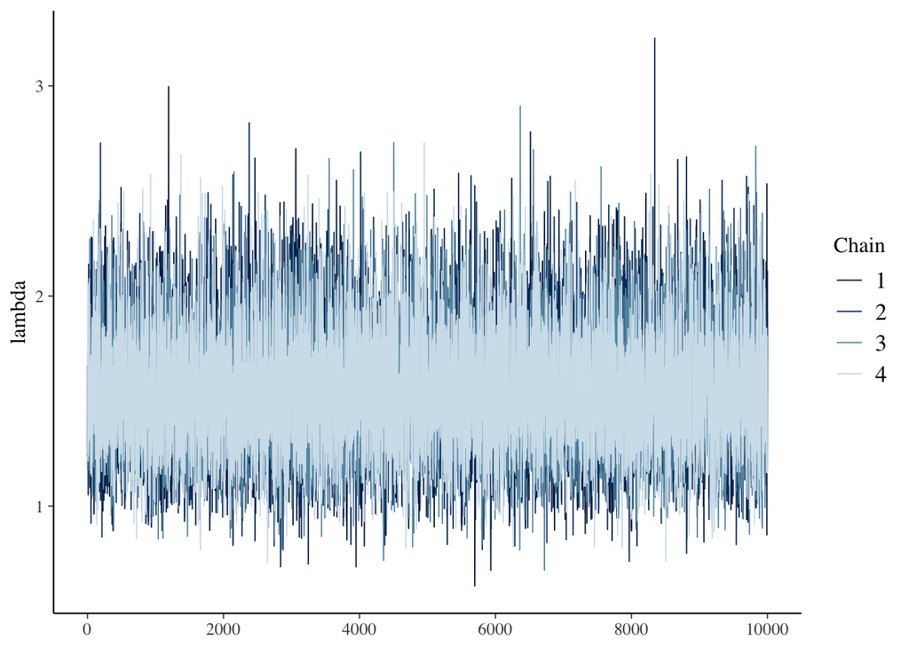

```r
mcmc_trace(sim823, pars = "lambda")
```

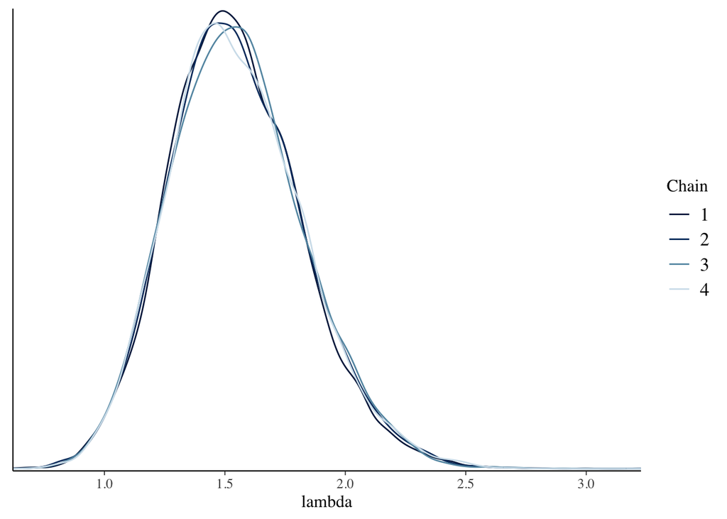

```r
mcmc_dens_overlay(sim823, pars = "lambda")
```

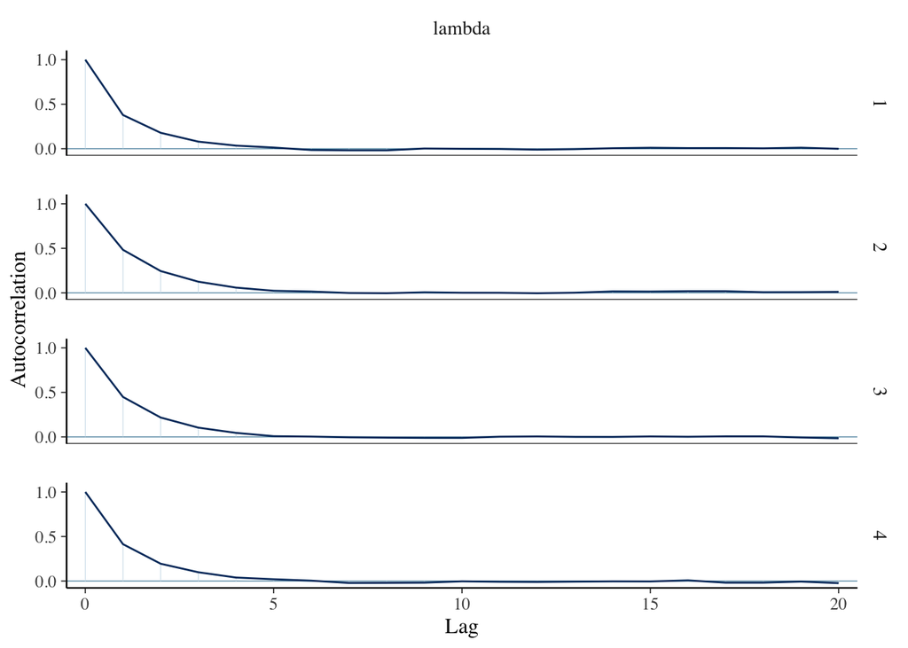

```r
mcmc_acf(sim823, pars = "lambda")
```

```r
neff_ratio(sim823, pars = "lambda")
```

```
## [1] 0.3835165
```

```r
rhat(sim823, pars = "lambda")
```

```
## [1] 1.000036
```

Trace plots look normal with no sticking points or obvious trends; density plots look similar across chains and point to a lambda of 1.5; autocorrelation drops to essentially 0 after a lag of 5, which is good; effective sample size ratio is .38, which is normal; and rhat is well below the 1.05 mark of concern. Overall, looks good!

### Part C

```r
# direct calculation...
loondf <- as.data.frame(sim823, pars = "lp__", include = FALSE)

loondf |>
  summarize(
    lower95 = quantile(lambda, .025),
    upper95 = quantile(lambda, .975)
    )
```

```
##    lower95  upper95
## 1 1.055452 2.143551
```

```r
# tidy shortcut
tidy(sim823, conf.int = TRUE, conf.level = .95)
```

```
## # A tibble: 1 × 5
##   term   estimate std.error conf.low conf.high
##   <chr>     <dbl>     <dbl>    <dbl>     <dbl>
## 1 lambda     1.53     0.276     1.06      2.14
```

95% CI: (1.06, 2.14)

### Part D

```r
loondf |>
  mutate(htest = lambda < 1) |>
  tabyl(htest)
```

```
##  htest     n percent
##  FALSE 39468  0.9867
##   TRUE   532  0.0133
```

The posterior probability that lambda < 1 is 1.33%.

### Part E

These values are EXTREMELY close to the actual values I calculated before (only off by hundredths, if at all.)

## Exercise 8.24

### Part A

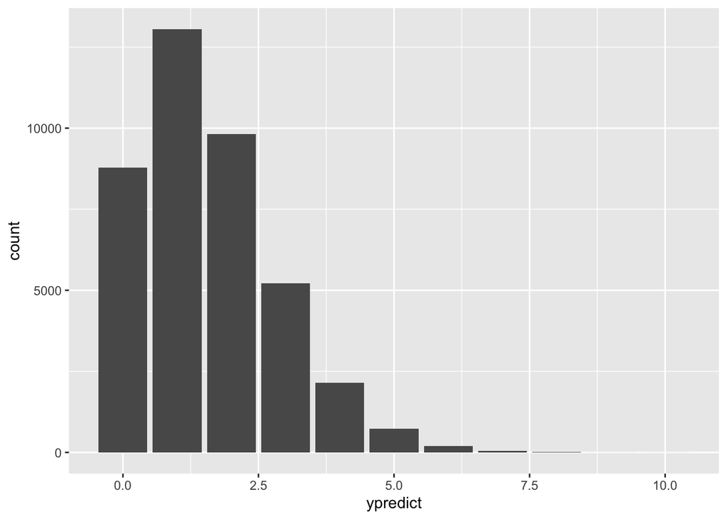

```r
loondf <- loondf |>
  mutate(ypredict = rpois(length(lambda), lambda=lambda))
ggplot(loondf, aes(x=ypredict)) +
  stat_count()
```

### Part B

The most likely number of loons is 1; the distribution of possible loons is skewed to the right, so it is possible to see 6 or even 7 loons (though not likely).

### Part C

```r
loondf |>
  mutate(loontest = ypredict < 1) |>
  tabyl(loontest)
```

```
##  loontest     n percent
##     FALSE 31224  0.7806
##      TRUE  8776  0.2194
```